# Business Statistics Mid-Term Assessment IB94X0 2026-2027 Assignment 1

Zeeshan Khatib (Student ID: 5830521)

```r
library(tidyverse)
options(width=100)
```

# Section 1

Load dataset and assign it to variable data

```r
file_path = '/Users/zeeshankhatib/Desktop/Business Statistics Assignment 1/Underground_v_161026.csv' #Specify the file path to Underground_v_161026.csv file here
data <- read_csv(file_path)
```

Checking all the unique Railway Lines included in the dataset

```r
data %>%
  group_by(Line) %>%
  summarise(count=n())
```

```
## # A tibble: 9 × 2
##   Line              count
##   <chr>             <int>
## 1 Bakerloo            144
## 2 Central             144
## 3 Jubilee             142
## 4 Jubilee_XYZ           2
## 5 Northern            144
## 6 Piccadilly          144
## 7 Sub-surface_lines   144
## 8 Victoria            144
## 9 Waterloo_and_City   144
```

Changing Jubilee_XYZ into Jubilee, because there are only 2 instances of Jubilee_XYZ in the entire dataset, hence I’m assuming that it was a mistake in recording.

```r
data <- data %>%
  mutate(Line = if_else(Line == 'Jubilee_XYZ', 'Jubilee', Line))
```

Checking for duplication in name of months.

```r
data %>%
  group_by(Month) %>%
  summarise(n())
```

```
## # A tibble: 12 × 2
##    Month     `n()`
##    <chr>     <int>
##  1 April        96
##  2 August       96
##  3 December     96
##  4 February     96
##  5 January      96
##  6 July         96
##  7 June         96
##  8 March        96
##  9 May          96
## 10 November     96
## 11 October      96
## 12 September    96
```

Checking for any missing ID values

```r
filter(data, is.na(ID))
```

```
## # A tibble: 7 × 5
##   ID     Year Month     Line               Temp
##   <chr> <dbl> <chr>     <chr>             <dbl>
## 1 <NA>   2013 December  Victoria           20
## 2 <NA>   2015 September Waterloo_and_City  24.0
## 3 <NA>   2016 June      Central            28.0
## 4 <NA>   2022 April     Bakerloo           24.8
## 5 <NA>   2022 June      Jubilee            24.1
## 6 <NA>   2024 March     Waterloo_and_City  18.5
## 7 <NA>   2024 June      Waterloo_and_City  22.2
```

Replacing the missing ID values with {TFL followed by five digits, appropriate no of zeroes followed by the index number of the row}

For example: Row 1: `TFL00001`, Row 12: `TFL00012`, Row 125: `TFL00125`

(DISCLOSURE: I did use the help of ChatGPT for the paste0() & sprintf() functions)

```r
data <- data %>%
  mutate(ID = if_else( is.na(ID), paste0("TFL", sprintf("%05d", row_number())), ID))
```

Rechecking if there are any missing ID values left in our data.

```r
filter(data, is.na(ID))
```

```
## # A tibble: 0 × 5
## # ℹ 5 variables: ID <chr>, Year <dbl>, Month <chr>, Line <chr>, Temp <dbl>
```

Checking how many NA temperature measures are there in the data.

```r
data %>%
  group_by(Temp) %>%
  summarise(n()) %>%
  filter(is.na(Temp))
```

```
## # A tibble: 1 × 2
##    Temp `n()`
##   <dbl> <int>
## 1    NA    11
```

Viewing all the entries where temperature is not recorded.

```r
filter(data, is.na(Temp))
```

```
## # A tibble: 11 × 5
##    ID        Year Month    Line               Temp
##    <chr>    <dbl> <chr>    <chr>             <dbl>
##  1 TFL00036  2013 May      Northern             NA
##  2 TFL00061  2013 August   Piccadilly           NA
##  3 TFL00155  2014 August   Jubilee              NA
##  4 TFL00224  2015 April    Sub-surface_lines    NA
##  5 TFL00319  2016 April    Waterloo_and_City    NA
##  6 TFL00333  2016 June     Piccadilly           NA
##  7 TFL00399  2017 February Waterloo_and_City    NA
##  8 TFL00581  2019 January  Piccadilly           NA
##  9 TFL00821  2021 July     Piccadilly           NA
## 10 TFL01037  2023 October  Piccadilly           NA
## 11 TFL01149  2024 December Piccadilly           NA
```

Removing all the rows where no temperature was recorded, as these are redundancies and will negatively impact our analysis.

```r
data <- data %>%
  filter(!is.na(Temp))
```

Rechecking to see if there are any rows with missing Temperatures still left in our data.

```r
filter(data, is.na(Temp))
```

```
## # A tibble: 0 × 5
## # ℹ 5 variables: ID <chr>, Year <dbl>, Month <chr>, Line <chr>, Temp <dbl>
```

Checking the mean, median, standard deviation, minimum and maximum Temperature across the entire data and also for each individual line.

```r
data %>% summarise(mean_overall_temp = mean(Temp), meadian_overall_temp = median(Temp), stdev_overall_temp = sd(Temp), min_overall_temp = min(Temp), max_overall_temp = max(Temp))
```

```
## # A tibble: 1 × 5
##   mean_overall_temp meadian_overall_temp stdev_overall_temp min_overall_temp max_overall_temp
##               <dbl>                <dbl>              <dbl>            <dbl>            <dbl>
## 1              24.1                 23.9               11.9             0.27             267.
```

```r
data %>%
  group_by(Line) %>%
  summarise(mean = mean(Temp), meadian = median(Temp), stdev = sd(Temp), min = min(Temp), max= max(Temp))
```

```
## # A tibble: 8 × 6
##   Line               mean meadian stdev   min   max
##   <chr>             <dbl>   <dbl> <dbl> <dbl> <dbl>
## 1 Bakerloo           26.6    26.6  3.42  0.27  32.4
## 2 Central            25.9    25.6  3.48  2.32  31.3
## 3 Jubilee            23.4    21.9 15.7  16.4  206.
## 4 Northern           24.6    24.6  3.06  2.74  29.5
## 5 Piccadilly         23.3    22.7  2.74 18.7   28.6
## 6 Sub-surface_lines  20.3    17.8 19.6  11.2  247.
## 7 Victoria           27.3    25.9 20.3  17.7  267.
## 8 Waterloo_and_City  20.9    21.1  3.38  1.05  26.5
```

In the overall summary table I noticed that the max temperature is showing as 267 Degree Celsius, which seems a bit off. Hence I go ahead and check how many rows have a temperature greater than 45 degree Celsius, because I’m assuming that any temperature above 45 degrees in London is very unusual and most probably is an error in recording.

```r
filter(data, round(Temp,2) > 45.00)
```

```
## # A tibble: 3 × 5
##   ID        Year Month    Line               Temp
##   <chr>    <dbl> <chr>    <chr>             <dbl>
## 1 TFL00307  2016 March    Jubilee            206.
## 2 TFL00440  2017 July     Sub-surface_lines  247.
## 3 TFL00470  2017 November Victoria           267.
```

After running the above line of code I see that there are 3 instances of unusually high temperatures recorded, all being 200+ , This of course is an error in recording and I’m assuming that the person recording this data misplaced the decimal point by one decimal space, and so I divided these three values by 10. This way the temperatures recorded stand corrected.

```r
data <- mutate(data, Temp = if_else(Temp > 50, Temp/10, Temp))
```

Checking for abnormally low temperatures

```r
arrange(data, Temp)
```

```
## # A tibble: 1,141 × 5
##    ID        Year Month     Line               Temp
##    <chr>    <dbl> <chr>     <chr>             <dbl>
##  1 TFL00121  2014 April     Bakerloo           0.27
##  2 TFL00735  2020 August    Waterloo_and_City  1.05
##  3 TFL00530  2018 July      Central            2.32
##  4 TFL00452  2017 September Northern           2.74
##  5 TFL00776  2021 January   Sub-surface_lines 11.2
##  6 TFL00016  2013 February  Sub-surface_lines 11.3
##  7 TFL00024  2013 March     Sub-surface_lines 11.4
##  8 TFL00496  2018 February  Sub-surface_lines 11.6
##  9 TFL00008  2013 January   Sub-surface_lines 11.9
## 10 TFL00392  2017 January   Sub-surface_lines 12.0
## # ℹ 1,131 more rows
```

After running the above line of code we can see that there are 4 outliers which show much lower temperatures as compared to others.To investigate whether these values are genuine anomalies or reflect unusual temperature patterns, I examine the temperatures recorded for the corresponding Underground lines and months in previous years. This allows me to compare the observations against historical patterns and assess whether the unusually low temperatures are plausible.

```r
filter(data, Month == 'April' & Line == 'Bakerloo')
```

```
## # A tibble: 12 × 5
##    ID        Year Month Line      Temp
##    <chr>    <dbl> <chr> <chr>    <dbl>
##  1 TFL00025  2013 April Bakerloo 23.7
##  2 TFL00121  2014 April Bakerloo  0.27
##  3 TFL00217  2015 April Bakerloo 25.5
##  4 TFL00313  2016 April Bakerloo 24.9
##  5 TFL00409  2017 April Bakerloo 27.0
##  6 TFL00505  2018 April Bakerloo 25.9
##  7 TFL00601  2019 April Bakerloo 26.8
##  8 TFL00697  2020 April Bakerloo 25.5
##  9 TFL00793  2021 April Bakerloo 23.3
## 10 TFL00889  2022 April Bakerloo 24.8
## 11 TFL00985  2023 April Bakerloo 24.4
## 12 TFL01081  2024 April Bakerloo 25.0
```

```r
filter(data, Month == 'August' & Line == 'Waterloo_and_City')
```

```
## # A tibble: 12 × 5
##    ID        Year Month  Line               Temp
##    <chr>    <dbl> <chr>  <chr>             <dbl>
##  1 TFL00063  2013 August Waterloo_and_City 25.1
##  2 TFL00159  2014 August Waterloo_and_City 25.2
##  3 TFL00255  2015 August Waterloo_and_City 25.1
##  4 TFL00351  2016 August Waterloo_and_City 26.0
##  5 TFL00447  2017 August Waterloo_and_City 25.2
##  6 TFL00543  2018 August Waterloo_and_City 26.3
##  7 TFL00639  2019 August Waterloo_and_City 25.3
##  8 TFL00735  2020 August Waterloo_and_City  1.05
##  9 TFL00831  2021 August Waterloo_and_City 21.3
## 10 TFL00927  2022 August Waterloo_and_City 25.0
## 11 TFL01023  2023 August Waterloo_and_City 23.7
## 12 TFL01119  2024 August Waterloo_and_City 24.1
```

```r
filter(data, Month == 'July' & Line == 'Central')
```

```
## # A tibble: 12 × 5
##    ID        Year Month Line     Temp
##    <chr>    <dbl> <chr> <chr>   <dbl>
##  1 TFL00050  2013 July  Central 30
##  2 TFL00146  2014 July  Central 30.5
##  3 TFL00242  2015 July  Central 29.8
##  4 TFL00338  2016 July  Central 29.6
##  5 TFL00434  2017 July  Central 30.6
##  6 TFL00530  2018 July  Central  2.32
##  7 TFL00626  2019 July  Central 30.7
##  8 TFL00722  2020 July  Central 28.6
##  9 TFL00818  2021 July  Central 29.3
## 10 TFL00914  2022 July  Central 30.3
## 11 TFL01010  2023 July  Central 30.0
## 12 TFL01106  2024 July  Central 29.8
```

```r
filter(data, Month == 'September' & Line == 'Northern')
```

```
## # A tibble: 12 × 5
##    ID        Year Month     Line      Temp
##    <chr>    <dbl> <chr>     <chr>    <dbl>
##  1 TFL00068  2013 September Northern 25.1
##  2 TFL00164  2014 September Northern 26.5
##  3 TFL00260  2015 September Northern 26.8
##  4 TFL00356  2016 September Northern 28.3
##  5 TFL00452  2017 September Northern  2.74
##  6 TFL00548  2018 September Northern 28
##  7 TFL00644  2019 September Northern 28.4
##  8 TFL00740  2020 September Northern 27.5
##  9 TFL00836  2021 September Northern 27.5
## 10 TFL00932  2022 September Northern 28.1
## 11 TFL01028  2023 September Northern 28.8
## 12 TFL01124  2024 September Northern 27.9
```

Based on the historical comparisons, I infer that the unusually low temperatures resulted from misplaced decimal points during data entry. In three cases, the decimal point was misplaced by one position, while for Bakerloo in April 2014, it was misplaced by two positions. I therefore correct these errors using the following code.

```r
data <- data %>%
  mutate( Temp = if_else(ID=='TFL00121', Temp *100, Temp))

data <- data %>%
  mutate(Temp = if_else(ID %in% c('TFL00735','TFL00530','TFL00452'), Temp*10, Temp))

view(data)
```

Creating a new tibble which does not include the Sub-surface_lines.

```r
new_data <- data %>%
  filter(Line != 'Sub-surface_lines')
```

Importing relevant libraries for plotting the data

```r
library(ggplot2)
library(gridExtra)
```

Checking for how many temperature recordings we have for each of the lines in the year 2022

```r
new_data %>%
  filter(Year == 2022) %>%
  group_by(Line) %>%
  summarise(n())
```

```
## # A tibble: 7 × 2
##   Line              `n()`
##   <chr>             <int>
## 1 Bakerloo             12
## 2 Central              12
## 3 Jubilee              12
## 4 Northern             12
## 5 Piccadilly           12
## 6 Victoria             12
## 7 Waterloo_and_City    12
```

Plotting the distribution of average monthly temperatures across all lines in 2022. I specifically used the year 2022 because we have records of temperature readings for all months in all the lines during that year.

(DISCLOSURE: I used ChatGPT to get to know about the built in character vectors month.abb & month.name and the functions theme() & element_rect() in R)

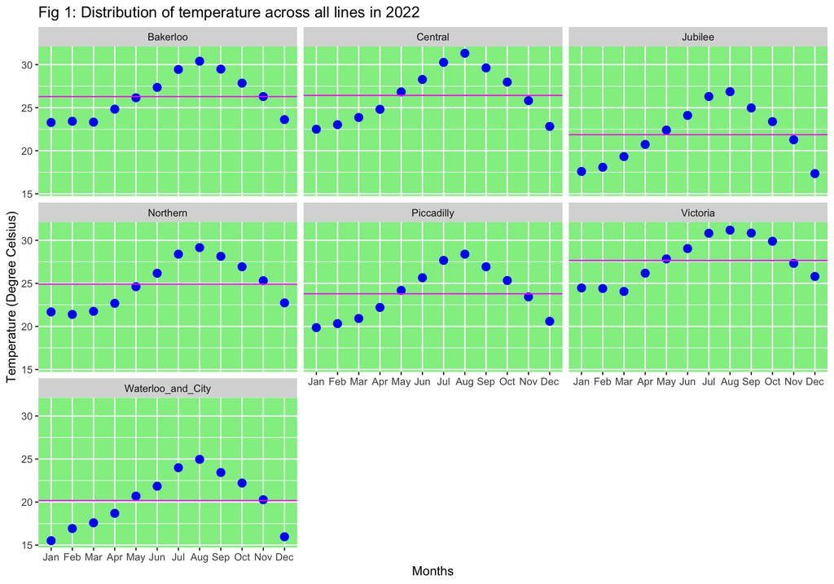

```r
mean_temp <- new_data %>%
  filter(Year == 2022) %>%
  group_by(Line) %>%
  summarise(mean_temp = mean(Temp))


ggplot(data = filter(new_data, Year == 2022)) + geom_point(mapping = aes(x= Month, y= Temp), colour = 'blue', size=3) + facet_wrap(~ Line) +  scale_x_discrete(limits = month.name, labels= month.abb) + labs(x= 'Months', y= 'Temperature (Degree Celsius)', title= 'Fig 1: Distribution of temperature across all lines in 2022') + theme(panel.background = element_rect(fill = "lightgreen")) + geom_hline(data = mean_temp, aes(yintercept = mean_temp), col = "magenta")
```

Plotting Monthly Temperature readings Pooled Across All Lines In 2022

(DISCLOSURE: I used ChatGPT for the scale_colour_manual() function)

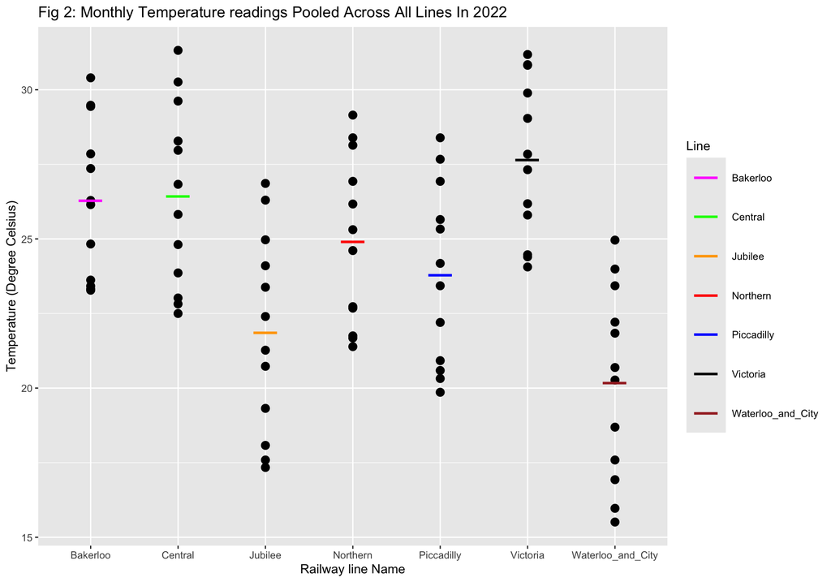

```r
ggplot(data= filter(new_data, Year == 2022)) + geom_point(mapping = aes(x= Line, y= Temp), size=3) + labs(x= 'Railway line Name', y= 'Temperature (Degree Celsius)', title= 'Fig 2: Monthly Temperature readings Pooled Across All Lines In 2022') + geom_point(data = mean_temp, mapping = aes(x = Line, y = mean_temp, colour = Line), shape = 95, size = 12) + scale_colour_manual(values = c("magenta", "green", "orange","red", "blue", "black", "brown"))
```

Created a new tibble containing rows from only Central and Jubilee Line

```r
jubilee.vs.central <- new_data %>%
  filter(Line %in% c('Central','Jubilee') )

view(jubilee.vs.central)
```

Calculating the mean and standard deviation for temperatures in Central and Jubilee line

```r
jubilee.vs.central %>%
  group_by(Line) %>%
  summarise(mean = mean(Temp), StDev = sd(Temp))
```

```
## # A tibble: 2 × 3
##   Line     mean StDev
##   <chr>   <dbl> <dbl>
## 1 Central  26.1  2.86
## 2 Jubilee  22.1  2.81
```

Performing a two-sample t-test between the average temperature in Jubilee and Central lines.

```r
t.test(Temp~Line, data = jubilee.vs.central)
```

```
##
##  Welch Two Sample t-test
##
## data:  Temp by Line
## t = 11.77, df = 284.96, p-value < 2.2e-16
## alternative hypothesis: true difference in means between group Central and group Jubilee is not equal to 0
## 95 percent confidence interval:
##  3.285156 4.604631
## sample estimates:
## mean in group Central mean in group Jubilee
##              26.09021              22.14531
```

Performing a two-sample t-test between the average temperature in Jubilee and Central lines only for the summer months (May, June, July and August).

```r
t.test(Temp~Line, data = filter(jubilee.vs.central, Month %in% c('May','June','July','August')))
```

```
##
##  Welch Two Sample t-test
##
## data:  Temp by Line
## t = 10.01, df = 92.198, p-value < 2.2e-16
## alternative hypothesis: true difference in means between group Central and group Jubilee is not equal to 0
## 95 percent confidence interval:
##  3.086192 4.613861
## sample estimates:
## mean in group Central mean in group Jubilee
##              28.56875              24.71872
```

```r
jubilee.vs.central <- jubilee.vs.central %>%
  mutate(Month = factor(Month, levels = month.name, ordered = TRUE))
```

# Section 2 Professionally formatted report for managers.

Fig 1 illustrates the distribution of average monthly temperatures across all railway lines in 2022. The magenta line represents the average temperature for each respective line. We can observe that temperatures generally peak around July–August and are at their lowest in December and January. Among all the lines, Victoria has the highest average temperature, at approximately 27.5°C.

Fig 2 presents the monthly temperature readings pooled across all railway lines for 2022. It further highlights the difference between the lines, with Victoria recording the highest average temperature and Waterloo & City the lowest, at approximately 20°C.

For the first two-sample t-test, I compare the average temperatures of the Jubilee and Central lines across the entire year. The null hypothesis states that the difference between their mean temperatures is zero, while the alternative hypothesis states that it is not zero. The p-value is less than 2.2e-16, providing strong evidence to reject the null hypothesis. This suggests that the difference in average temperatures between the two lines is statistically significant.

For the second t-test, I repeat the comparison using only the summer months. Once again, the p-value is less than 2.2e-16, indicating a statistically significant difference in average temperatures between the two lines during summer as well.

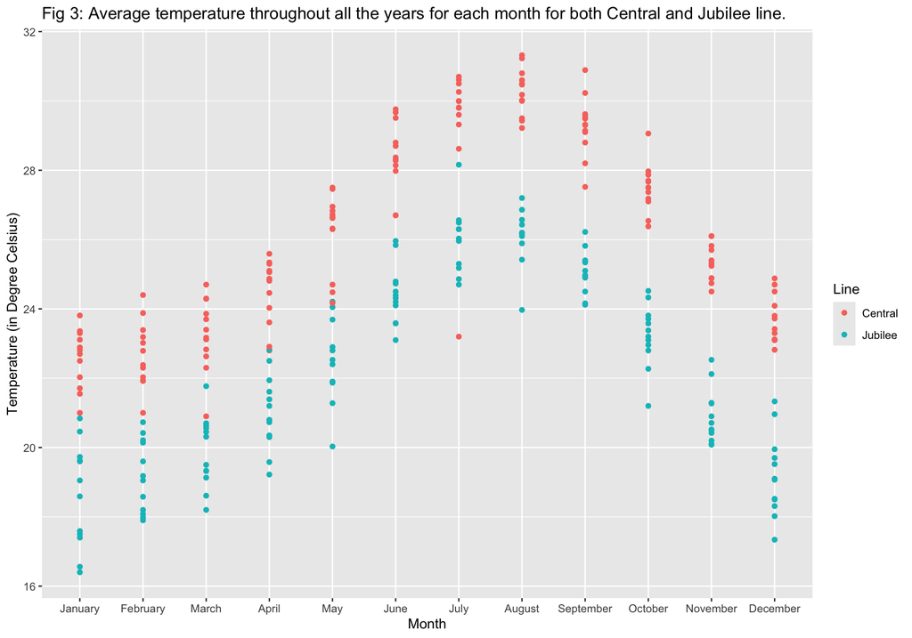

```
## # A tibble: 12 × 3
##    Month     Central Jubilee
##    <ord>       <dbl>   <dbl>
##  1 January      22.6    18.6
##  2 February     22.7    19.2
##  3 March        23.3    19.9
##  4 April        24.5    21.0
##  5 May          26.2    22.5
##  6 June         28.4    24.4
##  7 July         29.4    26.0
##  8 August       30.3    26.1
##  9 September    29.3    25.1
## 10 October      27.5    23.2
## 11 November     25.3    20.9
## 12 December     23.7    19.2
```

Based on Fig 3 and the table above, I would recommend installing an air conditioning system on the Central line, as its average temperatures are consistently higher than those of the Jubilee line across the months. The results of both t-tests further support this recommendation, confirming that the difference in average temperatures between the two lines is statistically significant.